14.5.2019

# Voiko vaalikoneen vastauksista ennustaa ehdokkaan puolueen?

## Antti J. Tanskanen

Yle on julkaissut Eduskuntavaaleja varten tehdyn Ylen vaalikoneen aineiston avoimena datana (https://vaalikone.yle.fi/). Aineistossa on mukana noin 2 200 Eduskuntavaalien ehdokkaalle esitetyt väitteet, perustiedot ehdokkaista (tosin ilman nimiä) ja ehdokkaiden vastaukset.

Aineiston avulla voi esimerkiksi arvioida, miten hyvin ehdokkaiden vastaukset kuvastavat puoluetta, jota he edustavat. Tämä on tavoitteena tässä blogissa, jossa rakennetaan koneoppimista hyödyntäen luokittelija. Luokittelija katsoo, mitä ehdokas vastasi vaalikoneen väitteisiin, ja sen perusteella arvioi mihin puolueeseen ehdokas kuuluu.

Luokittelutulokset osoittavat, että Eduskuntaan valittujen ehdokkaiden puoluekanta on helpompi päätellä vastauksista kuin kaikkien ehdokkaiden. Kiinnostavaa on myös se, minkä puolueiden kohdalla luokittelija ei onnistu ennustamaan ehdokkaiden puoluekantaa. Tämä saattaa kertoa siitä, että ko. puolueissa on erilaisia näkösuuntia tai vakiintumaton ideologia. Tiedämme esimerkiksi, että RKP:ssä yhdistävä tekijä on ruotsinkieli vahvemmin kuin mikään poliittinen ideologia, jolloin voi odottaa etteivät RKP:n ehdokkaat ole kovin yhtenäisiä vastauksissaan.

Malli laittaa myös vaalikonedatan väitteet luokittelun osalta tärkeysjärjestykseen. Tärkeimpänä puolueita erottavana väitteenä näyttäytyy "Euron ulkopuolella Suomi pärjäisi paremmin".

## Luokittelija Ylen vaalikoneen aineistolle

Luokittelu on perinteisiä koneoppimisen vahvoja alueita, ja siihen tunnetaan lukuisia menetelmiä, esimerkiksi neuroverkot ja boostatut algoritmit. Käytetään tässä Microsoftin LightGBM-luokittelijaa (boostattu algoritmi), jota on käytetty menestyksellä esimerkiksi Kagglen koneoppimiskilpailuissa.

Luokittelija opetetaan Ylen vaalikonedatan avulla. Luokittelija käyttää ainoana tietona vaalikoneen dataa, mitään muuta aineistoa ei käytetä. Aineistosta valitaan helppouden vuoksi vain monivalintatehtävät. Tällöin vapaat vastaukset jäävät pois. Myös ikä, äidinkieli ja tieto valinnasta Eduskuntaan jätetään aineistosta pois.

Tarkoitus on ennustaa ehdokkaiden puolue vastauksista kaikille esitettyihin väitteisiin annettujen vastausten perusteella. Tästä syystä alueelliset väitteet on rajattu pois. Jäljelle jää 29 väitettä, joiden perusteella ehdokkaiden puoluekanta ennustetaan.

Koska tavoitteena on tutkia mallin opetusaineiston ulkopuoisia ennusteita, jaetaan data opetus- ja testiaineistoon. Opetusaineistolla koulutetaan luokittelija, jonka ennustusvoimaa arvioidaan testiaineiston ennusteiden avulla (out of sample). Toistetaan sama viisi kertaa niin, että otetaan aineistosta 80 % opetusaineistoksi ja 20 % testiaineistoksi valiten testiaineistoksi aina eri osa aineistoa. Tällöin saamme out-of-sample ennusteen kaikille ehdokkaille.

Hieman yksinkertaistaen, luokittelija etsii ensin opetusaineistosta tiedon siitä, mitkä tekijät kuvaavat mitäkin puoluetta, ja tämän jälkeen se ennustaa testiaineiston vastauksista testiaineistossa olevien ehdokkaiden puoluekannan.

## Miten hyvin ehdokkaan puolue löyty?

Sovitetaan aluksi malli. Kun malli on sovitettu, testataan miten hyvin se toimii. Alla on luokittelijan ennustustarkkuus viidessä testiaineistosiivussa.

```
Siivu 1: Osumistarkkuus 58.19672131147541 %
Siivu 2: Osumistarkkuus 60.040983606557376 %
Siivu 3: Osumistarkkuus 55.64681724845995 %
Siivu 4: Osumistarkkuus 57.70020533880903 %
Siivu 5: Osumistarkkuus 54.41478439425052 %
Osumistarkkuus 57.19990237991045 %
```

Malli ennustaa keskimäärin 57 prosentin (vaihteluväli 54 - 60 prosenttia) tarkkuudella ehdokkaan puolueen täsmälleen oikein, ehdokkaan vastausten perusteella. Kun aineistossa on 21 puoluetta, on tarkkuus kohtuullinen.

Katsotaan ensin, menevätkö puolueet sekaisin vastausten perusteella. Tätä voi tarkastella nk. Sekaannusmatriisilla (engl. Confusion matrix), joka näyttää missä määrin ennusteet menevät kohdalleen. Pystyakselilla on ehdokkaan oikea puolue, vaaka-akselilla vastauksista ennustettu puolue. Jos kaikki ennusteet olisivat täydellisiä, lukuja olisi vain matriisin diagonaalilla. Kaikki diagonaalin ulkopuolella oleva ennusteet ovat vääriä.

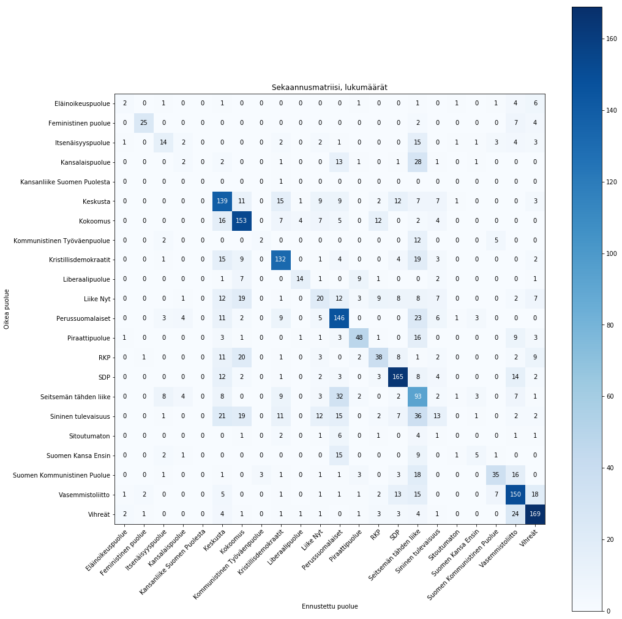

Luokittelijan mielestä esimerkiksi Keskustan ehdokkaista asemoituu mielipiteidensä puolesta 11 Kokoomukseen, 15 Kristillisdemokraatteihin ja 12 SDP:hen. Ehkä erikoisin tulos on Sinisellä tulevaisuudella, jonka ehdokkaista suurin osa sijoittuu luokittelijan mielestä muualle kuin Siniseen tulevaisuuteen.

Yllättävä on myös Seitsemän tähden liike, johon luokittelija sijoittaa monta muiden puolueiden ehdokkaista. Selitys saattaa olla esimerkiksi se, että Seitsemän tähden liikkeen ehdokkailla ei ole kovin yhtenäisiä vastauksia vaalikoneen väitteisiin.

Alla Sekaannusmatriisi suhteellisilla osuuksilla.

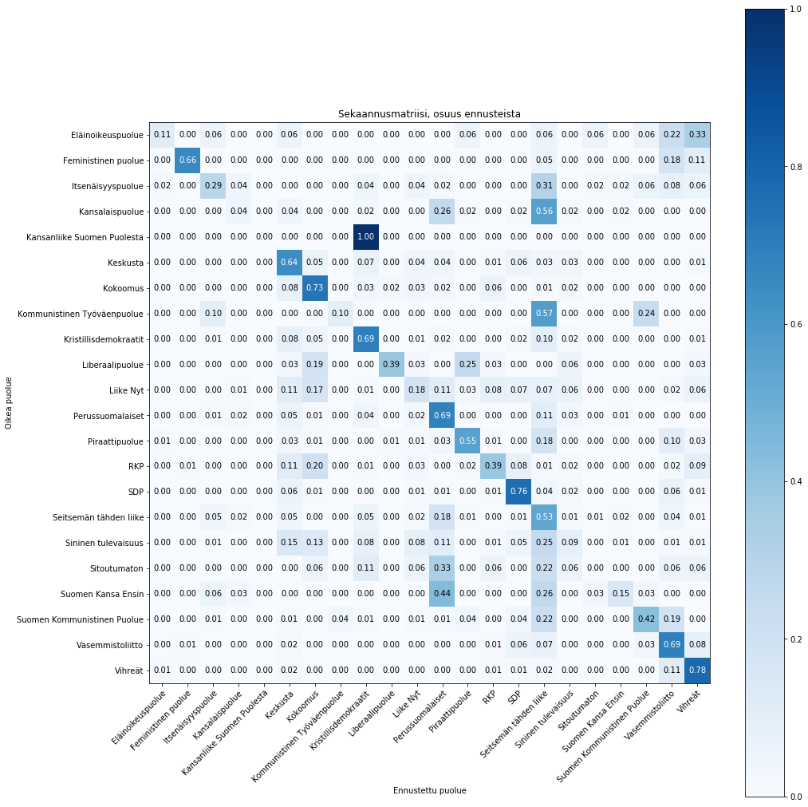

Parhaiten malli luokittelee Vihreiden ehdokkaat oikeaan puolueeseen: 78 prosenttia ehdokkaista luokittuu vastausten perusteella Vihreiksi. Lähes yhtä hyvin malli luokittelee SDP:n ja Kokoomuksen ehdokkaat.

Vihreiden ehdokkaista 11 prosenttia luokittuu Vasemmistoliittoon, ja vastaavasti 8 prosenttia Vasemmistoliiton ehdokkaista luokittuu Vihreiden ehdokkaiksi. Eläinoikeuspuolueen ehdokkaista suurempi osa luokitellaan Vihreisiin ja Vasemmistoliittoon kuin Eläinoikeuspuolueeseen.

## Tärkeimmät vaalikoneen väitteet

Mallilla on mahdollista löytää ne väitteet, jotka erottavat eri puolueiden ehdokkaita. Alla tärkeysjärjestyksessä. Palkin leveys kertoo, miten tärkeä väite on, ja pieni musta vaakaviiva epävarmuuden tärkeysarviossa.

Tulosten mukaan väite "Euron ulkopuolella Suomi pärjäisi paremmin." erottaa ehdokkaat merkitsevimmin toisistaan. Myös suhtautuminen perustuloon näyttää jakavan ehdokkaita ja puolueita voimakkaasti, samoin kuin Nato.

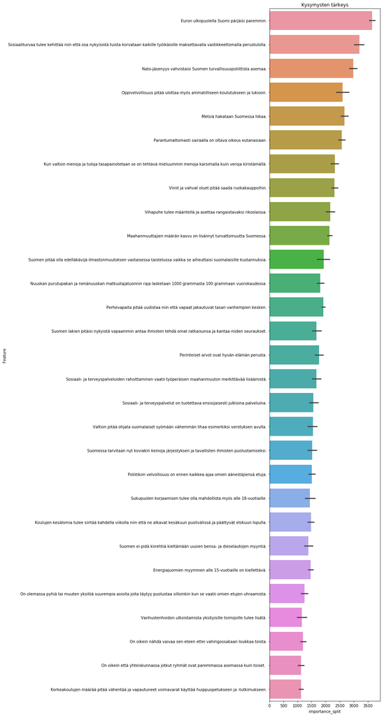

# Eduskuntapuolueet

Yllä tuloksissa on mukana sellaisten puolueiden ehdokkaita, jotka eivät päässeet vaaleissa Eduskuntaan. Heidän luokittelunsa näyttää haastavalta verrattuna Eduskunnassa edustettuihin puolueisiin. Miten tulokset muuttuvat, jos tarkastellaan pelkästään Eduskuntapuolueita?

```
Siivu 1: Osumistarkkuus 71.8475073313783 %
Siivu 2: Osumistarkkuus 70.67448680351906 %
Siivu 3: Osumistarkkuus 73.90029325513197 %
Siivu 4: Osumistarkkuus 67.3529411764706 %
Siivu 5: Osumistarkkuus 70.29411764705881 %
Osumistarkkuus 70.81386924271176 %
```

Tarkkuus paranee selvästi, kuten yllä olevat osumistarkkuudetkin osoittavat. Aiemmin 57 prosenttia, nyt yli 70 prosenttia. Vastaavatulos näkyy myös sekaannusmatriisissa.

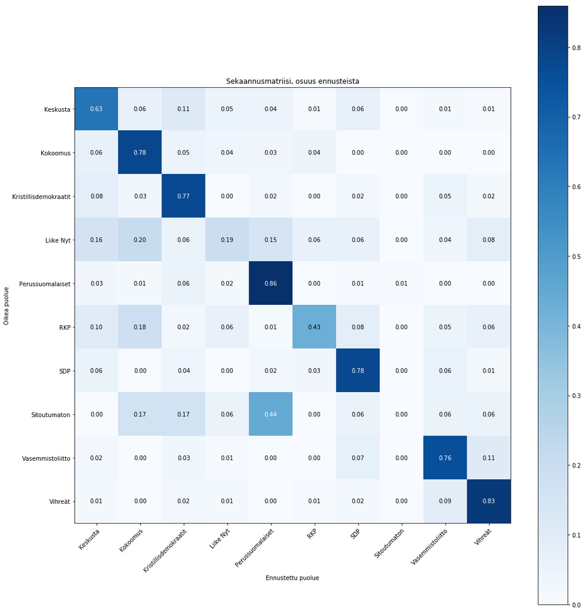

Tuloksista näkyy, että aiempaa suurempi osa ehdokkaista luokitellaan oikeaan puolueeseen. Hajonta on kuitenkin edelleen suurta, erityisesti Liike Nyt:issä, Sitoutumattomissa ja RKP:ssä. Toisin kuin muissa eduskuntapuolueissa, Liike Nytin ehdokkaat luokittuvat lähes tasaisesti kaikkiin muihin eduskuntapuolueisiin. Vastaava ilmiö on RKP:ssä, mutta ei yhtä voimakkaana.

Edelleen noin kymmenesosa Vihreistä voisi kuulua Vasemmistoliittoon ja päinvastoin. Perussuomalaiset erottuvat tässä jaottelussa hyvin selvästi muista puolueista: 86 prosenttia Perussuomalaisten ehdokkaista luokitellaan oikein.

Suurista puolueista Keskustan ehdokkaiden luokittelu menee eniten väärin: vain 63 prosentti ehdokkaista luokitellaan Keskustaan, ja 11 prosenttia luokitellaan Kristillisdemokraatteihin. 6 prosenttia ehdokkaista luokittuu Kokoomukseen ja saman verran SDP:hen.

# Eduskuntaan valitut

Entä jos tarkastellaan ylläsovitettuja malleja vain Eduskuntaan valittujen osalta? Miten hyvin heidän mielipiteensä vastasivat puolueiden kantoja?

Tarkkuus paranee merkittävästi. Nyt jo 85 prosenttia ennusteista on täsmälleen oikein, osalla puolueista kaikki.

```
Osumatarkkuus 0.85
```

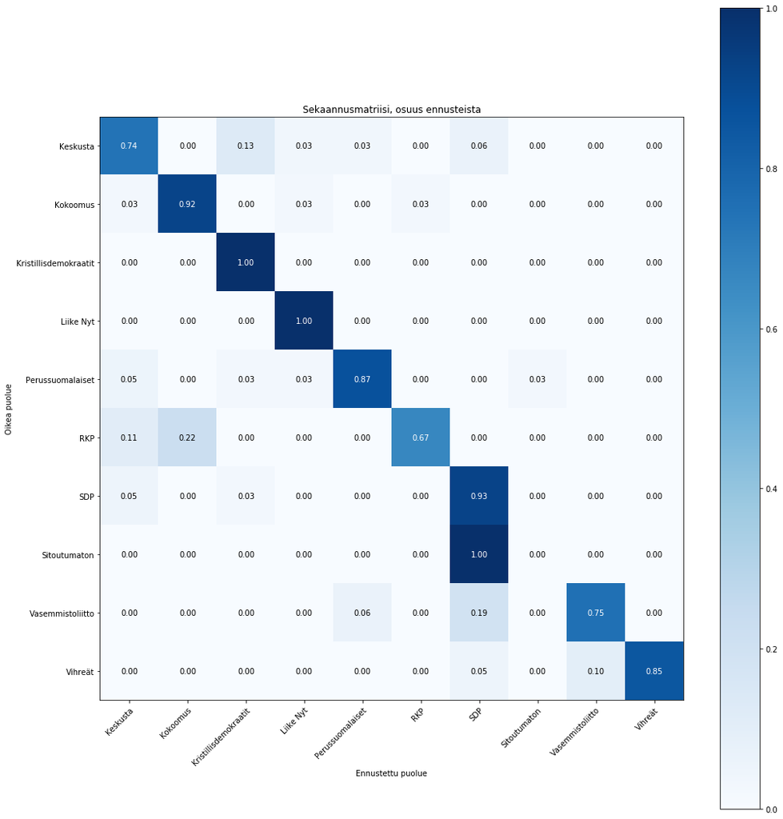

Yksittäisistä puolueista näkyy, että noin 13 prosenttia Keskustalaisista voisi olla Kristillisdemokraateissa mielipiteidensä perusteella luokiteltuna. Hieman yllättäen tässä kuviossa "vuoto" Vasemmistoliitosta Vihreisiin katoaa. Kuitenkin "vuoto" Vihreistä Vasemmistoliittoon säilyy ennallaan.

Sitoutumaton edustaja tulee Ahvenanmaalta. Ahvenanmaan edustaja kuuluu Ruotsalaiseen ryhmään (yhdessä RKP:n edustajien kanssa), mutta luokittelija sijoittaa hänet SDP:hen. Vastaavasti 19 prosenttia Vasemmistoliiton edustajista luokitellaan SDP:hen. Yllättävän merkittävä osuus RKP:läisistä voisi olla Keskustassa tai Kokoomuksessa.

## Kehityskohteita

Mallia olisi melko helppo parantaa sovittamalla LightGBM:n parametrejä paremmin (esim. Hyperopt:lla), muista menetelmistä puhumattakaan. Myös analysoimalla erilaisin menetelmin vapaisiin kenttiin annettuja vastauksia (esim. word2vec:llä) olisi tuloksia parannettavissa.

# Yhteenveto

Tulokset näyttävät, että pelkästään katsomalla eduskuntavaaliehdokkaiden vastauksia vaalikoneen väittämiin voi päätellä heidän puolueensa melko tarkasti. Ehdokkaista osa päätyy luokitelluksi väärään puolueeseen, erityisesti sellaisten puolueiden ehdokkaista, jotka eivät läpi päässeet. Eduskuntaan valittujen ehdokkaiden vastauksista voi päätellä heidän puolueensa ilman mitään muita tietoja erittäin hyvin. Tämä ehkä kertoo siitä, että valitut ehdokkaat edustavat hyvin puolueiden arvoja.

Tuloksissa on myös kiinnostavia väärin luokiteltuja ehdokkaita, esimerkiksi osa Keskustan edustajista luokitellaan Kristillisdemokraatteihin ja osa Vasemmistoliiton edustajista luokitellaan SDP:hen.